# 제 14강: 비선형 및 평활 회귀 II

데이터과학 입문

Author

Affiliation

원중호

서울대학교 통계학과

Published

May 2026

## 시작하기 전에

다음의 패키지가 설치되어 있지 않으면 설치한다.

**R**

```r
# install.packages("MASS")
# install.packages("tidyverse")
# install.packages("boot")
# install.packages("KernSmooth")
# install.packages("gam")
# install.packages("mars")
# install.packages("nnet")
library(MASS)
library(tidyverse)
library(boot)
library(KernSmooth)
library(gam)
library(mda)
library(nnet)
```

**Python**

```python
import session_info
import pandas as pd
import numpy as np
import statsmodels.api as sm
import statsmodels.formula.api as smf
import scipy.stats as stats
from plotnine import *

session_info.show()
```

```
-----
numpy               2.4.3
pandas              3.0.1
plotnine            0.15.3
scipy               1.17.1
session_info        1.0.0
statsmodels         0.14.6
-----
Python 3.12.12 | packaged by conda-forge | (main, Jan 27 2026, 00:04:03) [Clang 19.1.7 ]
macOS-26.2-arm64-arm-64bit
-----
Session information updated at 2026-05-31 23:07
```

# 평활회귀 – 1변수 함수 적합

## 산점도 평활화

- 목적: 연속형 반응변수 $y \in \mathbb{R}$ vs 연속형 설명변수 $x \in \mathbb{R}$의 산점도를 평활화한 곡선 얻기
- 곡선의 함수적 형태에 대해 거의 알지 못함
  - 1부와의 큰 차이!
- 고전적 방법
  - 제한된 범위의 변환 (예: 2차 및 3차 항을 모형에 추가)
  - 변수의 범위를 분할하고 조각별 상수 또는 조각별 함수를 사용

## `GAGurine` 자료

**R**

```r
as_tibble(GAGurine)
```

```
# A tibble: 314 × 2
     Age   GAG
   <dbl> <dbl>
 1  0     23
 2  0     23.8
 3  0     16.9
 4  0     18.6
 5  0.01  17.9
 6  0.01  25.9
 7  0.01  16.5
 8  0.01  26.3
 9  0.01  26.9
10  0.01  17.9
# ℹ 304 more rows
```

**Python**

```python
GAGurine = sm.datasets.get_rdataset('GAGurine', 'MASS').data
print(GAGurine)
```

```
       Age   GAG
0     0.00  23.0
1     0.00  23.8
2     0.00  16.9
3     0.00  18.6
4     0.01  17.9
..     ...   ...
309  17.08   2.5
310  17.14   2.2
311  17.23   2.2
312  17.30   1.9
313  17.67   9.3

[314 rows x 2 columns]
```

- 0–17세 어린이 314명의 소변 내 화학 물질 GAG 농도에 대한 자료
- 전진선택법은 6차 다항식을 제안

**R**

```r
GAG.lm <- lm(GAG ~ Age + I(Age^2) + I(Age^3) + I(Age^4) + I(Age^5) +
              I(Age^6) + I(Age^7) + I(Age^8), data=MASS::GAGurine)
anova(GAG.lm)
```

```
Analysis of Variance Table

Response: GAG
           Df  Sum Sq Mean Sq  F value    Pr(>F)
Age         1 12589.8 12589.8 593.5762 < 2.2e-16 ***
I(Age^2)    1  3750.8  3750.8 176.8409 < 2.2e-16 ***
I(Age^3)    1  1491.5  1491.5  70.3202 1.891e-15 ***
I(Age^4)    1   449.3   449.3  21.1814 6.137e-06 ***
I(Age^5)    1   174.3   174.3   8.2156 0.0044421 **
I(Age^6)    1   286.0   286.0  13.4831 0.0002842 ***
I(Age^7)    1    57.2    57.2   2.6979 0.1015115
I(Age^8)    1    44.9    44.9   2.1173 0.1466717
Residuals 305  6469.1    21.2
---
Signif. codes:  0 '***' 0.001 '**' 0.01 '*' 0.05 '.' 0.1 ' ' 1
```

```r
GAG.lm2 <- lm(GAG ~ Age + I(Age^2) + I(Age^3) + I(Age^4) + I(Age^5) +
              I(Age^6), data=GAGurine)
```

**Python**

```python
from statsmodels.stats.anova import anova_lm

formula_8 = 'GAG ~ Age + I(Age**2) + I(Age**3) + I(Age**4) + I(Age**5) + I(Age**6) + I(Age**7) + I(Age**8)'
GAG_lm = smf.ols(formula_8, data=GAGurine).fit()
anova_results = anova_lm(GAG_lm)
print(anova_results)
```

```
                df        sum_sq       mean_sq           F        PR(>F)
Age            1.0  12589.829331  12589.829331  593.576239  1.539388e-73
I(Age ** 2)    1.0   3750.818801   3750.818801  176.840913  3.869040e-32
I(Age ** 3)    1.0   1491.500214   1491.500214   70.320182  1.890575e-15
I(Age ** 4)    1.0    449.260431    449.260431   21.181408  6.137194e-06
I(Age ** 5)    1.0    174.253212    174.253212    8.215565  4.442147e-03
I(Age ** 6)    1.0    285.977344    285.977344   13.483055  2.841629e-04
I(Age ** 7)    1.0     57.222676     57.222676    2.697894  1.015115e-01
I(Age ** 8)    1.0     44.908179     44.908179    2.117299  1.466717e-01
Residual     305.0   6469.089716     21.210130         NaN           NaN
```

```python
formula_6 = 'GAG ~ Age + I(Age**2) + I(Age**3) + I(Age**4) + I(Age**5) + I(Age**6)'
GAG_lm2 = smf.ols(formula_6, data=GAGurine).fit()
```

**R**

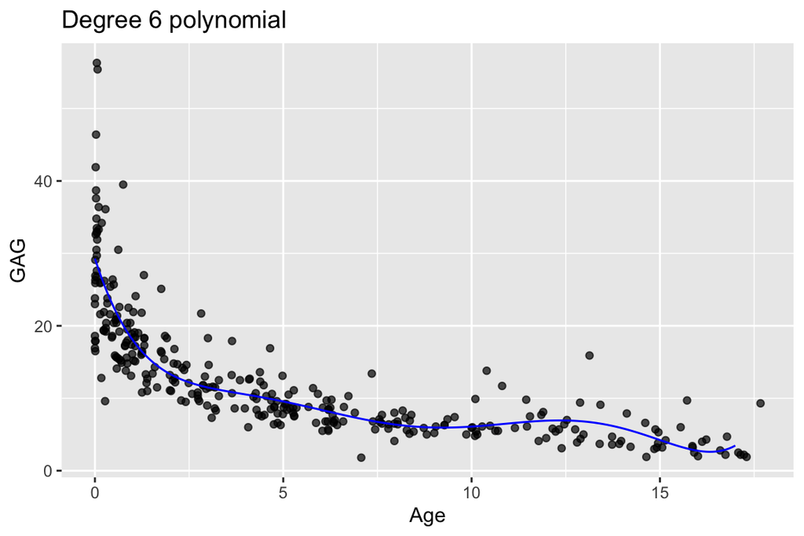

```r
mypred <- data.frame(Age = seq(0, 17, len = 200))
mypred$GAG <- predict(GAG.lm2, newdata = mypred)
ggplot(GAGurine, aes(x = Age, y = GAG)) +
  geom_point(alpha=0.7) +  # Scatterplot of points
  geom_line(data = mypred, aes(x = Age, y = GAG), color = "blue") +  # Polynomial regression line
  labs(title = "Degree 6 polynomial")
```

**Python**

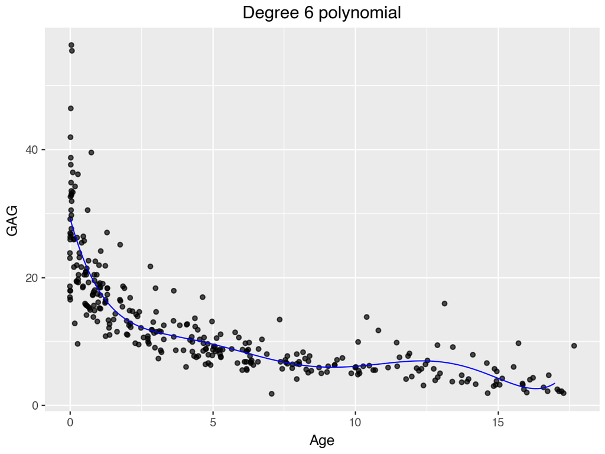

```python
mypred = pd.DataFrame({'Age': np.linspace(0, 17, 200)})
mypred['GAG'] = GAG_lm2.predict(mypred)
(
    ggplot(GAGurine, aes(x='Age', y='GAG'))
    + geom_point(alpha=0.7)
    + geom_line(data=mypred, mapping=aes(x='Age', y='GAG'), color='blue')
    + labs(title="Degree 6 polynomial")
).show()
```

### [스플라인](https://doi.org/10.1201/b15710)

- 수직선을 **매듭**(knot)이라 부르는 점의 순서집합 $\{ z_i \}$으로 분할
- 구간 $[z_i, z_{i+1}]$에서 3차 스플라인은 3차 다항식이며 연속인 1차 및 2차 도함수를 가짐
  - 각 매듭은 3개의 제약식을 만족
- 매듭이 $n$개인 경우 3차 스플라인을 나타내려면 $n+4$개의 모수가 필요
  - $4(n + 1)$개 자유도에서 $3n$ 연속 조건을 뺌
- B 스플라인 (basis splines): 임의의 스플라인 함수는 B 스플라인의 선형결합으로 표현 가능
- R 함수 `splines::bs()`는 B 스플라인 기저 행렬을 생성하여 선형 회귀 적합에 포함될 수 있음 (회귀 스플라인)

### 자연 3차 스플라인 (natural cubic splines)

- 경계 매듭(boundary knots) 바깥에서 선형이 되도록 B 스플라인을 제약
  - 내부 매듭 (internal knots) $n$개, 경계 매듭 2개: $n+2$개 모수
- R 함수 `splines::ns()`는 자유도 `df`를 지정하여 설명변수의 경험분포의 분위수로서 내부 매듭을, 최대최소값으로 경계 매듭을 선택할 수 있음
- 주의: 스플라인 모형으로부터의 예측은 함수의 기저가 설명변수의 관측치에 따라 달라지므로 주의가 필요.
  - `predict.lm()`을 사용하면 새로운 기저함수 집합이 형성되고 적합된 계수가 잘못 적용됨

### 평활 스플라인 (smoothing splines)

- $n$개의 순서쌍 $(x_i, y_i)$에 대해
  $$\sum w_i\left[y_i-f\left(x_i\right)\right]^2+\lambda \int\left(f^{\prime \prime}(x)\right)^2 \mathrm{~d} x$$
  을 최소화하는 두 번 미분가능한 함수 $f$를 적합
- $x_i$에 매듭이 있는 3차 스플라인
  - 자료점을 보간하지 않음($\lambda > 0$)
  - 자유도: $\operatorname{tr}(S_{\lambda})$, $S_{\lambda}$는 $\widehat{y}=S_{\lambda} y$인 $n \times n$ 행렬 (Green and Silverman, 1994, pp. 37-–8; Hastie, Tibshirani, and Friedman, 2009, Ch. 5)
- R 함수 `smooth.spline()`은 $\lambda$ 또는 자유도를 입력으로 받거나 그렇지 않으면 교차 검증을 통해 자동으로 $\lambda$를 선택

**R**

```r
attach(GAGurine)
GAG_ns5  <- lm(GAG ~ splines::ns(Age, df = 5))
GAG_ns10 <- lm(GAG ~ splines::ns(Age, df = 10))
GAG_ns20 <- lm(GAG ~ splines::ns(Age, df = 20))
GAG_sms  <- smooth.spline(Age, GAG)
xx <- seq(min(Age), max(Age), length.out = 200)
detach(GAGurine)
predicted05 <- predict(GAG_ns5,  newdata = data.frame(Age=xx))
predicted10 <- predict(GAG_ns10, newdata = data.frame(Age=xx))
predicted20 <- predict(GAG_ns20, newdata = data.frame(Age=xx))
predicted_sms <- predict(GAG_sms,  newdata = data.frame(Age=xx))
predicted_sms <- rename(as_tibble(predicted_sms), Age = x, GAG = y)
predicted_sms$df <- "Smoothing"
mypred <- data.frame(Age = xx, GAG = predicted05, df = "5")
mypred <- rbind(mypred, data.frame(Age = xx, GAG = predicted10, df = "10"))
mypred <- rbind(mypred, data.frame(Age = xx, GAG = predicted20, df = "20"))
mypred <- rbind(mypred, predicted_sms)
ggplot(GAGurine) +
  geom_point(aes(x=Age, y=GAG), alpha=0.5, size=0.5) +
  geom_line(data=mypred, aes(x=Age, y=GAG, color=df, linetype=df)) +
  labs(title = "Splines")
```

**Python**

```python
from scipy.interpolate import make_smoothing_spline

xx = np.linspace(GAGurine['Age'].min(), GAGurine['Age'].max(), 200)
predict_df = pd.DataFrame({'Age': xx})

# natural splines
models_ns = {}
for df_val in [5, 10, 20]:
    formula = f"GAG ~ cr(Age, df={df_val})"
    models_ns[df_val] = smf.ols(formula, data=GAGurine).fit()

# smoothing spline: sort and remove duplicates
sorted_df = GAGurine.sort_values('Age')
clean_df = sorted_df.groupby('Age')['GAG'].mean().reset_index()
x_sort = clean_df['Age'].values
y_sort = clean_df['GAG'].values
tck = make_smoothing_spline(x_sort, y_sort, lam=None) # GCV

# gather predictions
results = []
for df_val, model in models_ns.items():
    preds = model.predict(predict_df)
    results.append(pd.DataFrame({'Age': xx, 'GAG': preds, 'df': str(df_val)}))

results.append(pd.DataFrame({ 'Age': xx, 'GAG': tck(xx), 'df': 'Smoothing' }))

mypred = pd.concat(results)

(
    ggplot(GAGurine)
    + geom_point(aes(x='Age', y='GAG'), alpha=0.5, size=0.5)
    + geom_line(data=mypred, mapping=aes(x='Age', y='GAG', color='df', linetype='df'))
    + labs(title="Splines")
).show()
```

**R**

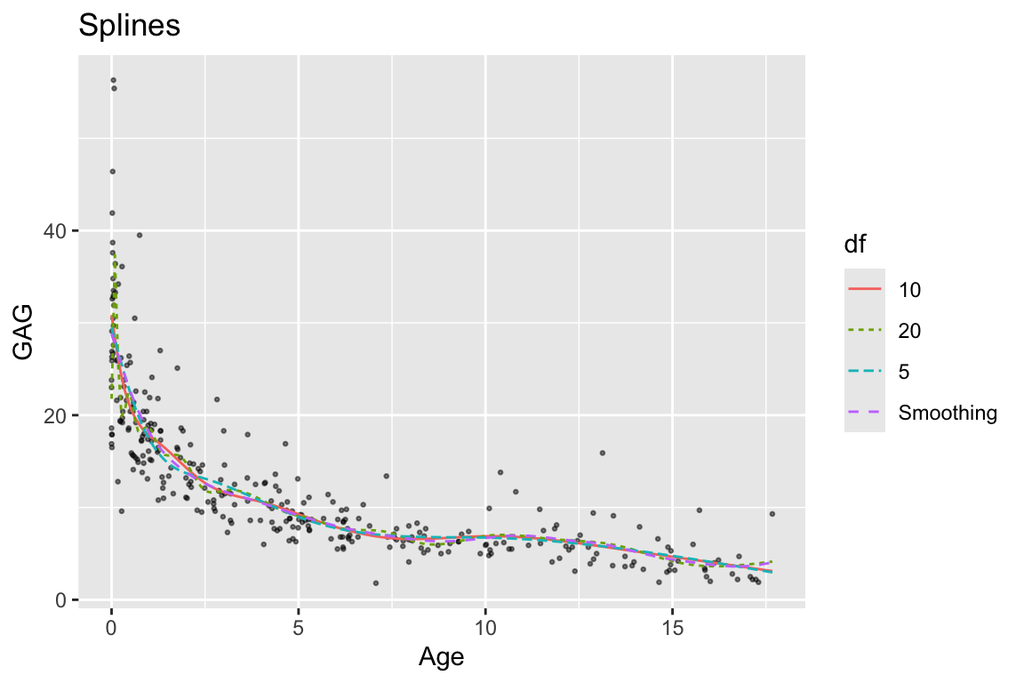

**Python**

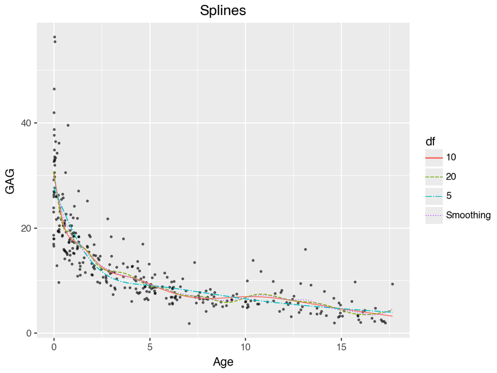

### 국소 회귀

- 주어진 값 $x$ 근방의 자료점에 선형 또는 다항식 회귀모형을 적합한 다음 $x$에서의 예측치를 평활화된 값으로 사용하여 작동하는 평활화 기법

#### `lowess` (locally weighted scatterplot smoothing, Cleveland, [(1979)](https://doi.org/10.1080/01621459.1979.10481038), [(1981)](https://doi.org/10.2307/2683591))

- $x$ 주위에 창(window)을 설정, $x$에 가까운 점이 가장 큰 가중치를 갖도록 창 내부의 자료점에 가중치 적용
- 강인(robust) 가중 회귀로 $x$에서 값을 예측
- 인수 `f`는 창에 포함되는 자료의 비율. 기본값 `f = 2/3`.

#### `loess` (locally estimated scatterplot smoothing, [Cleveland, Grosse and Shyu, 1992](https://doi.org/10.1201/9780203738535))

- 유사한 방식으로 1차원, 2차원 또는 그 이상의 차원에서 작동하는 `lowess` 개념의 확장

**R**

```r
attach(GAGurine)
mypred <- as.data.frame(loess.smooth(Age, GAG))
names(mypred) <- c("Age", "GAG")
detach(GAGurine)
ggplot(GAGurine, aes(x=Age, y=GAG)) +
  geom_point(alpha=0.75) +
  # default: predict(loess(y ~ x))
  geom_smooth(se=FALSE, color="magenta") +
  geom_line(data=mypred, aes(x=Age, y=GAG), color="blue") +
  labs(title = "loess")
```

**Python**

```python
lowess_results = sm.nonparametric.lowess(
    endog=GAGurine['GAG'],
    exog=GAGurine['Age'],
    frac=2/3
)
age_smooth, gag_smooth = lowess_results.T
mypred = pd.DataFrame({
    'Age': age_smooth,
    'GAG': gag_smooth
})
(
    ggplot(GAGurine, aes(x='Age', y='GAG'))
    + geom_point(alpha=0.75)
    + geom_smooth(method='lowess', se=False, color='magenta')
    + geom_line(data=mypred, mapping=aes(x='Age', y='GAG'), color='blue')
    + labs(title="loess")
).show()
```

**R**

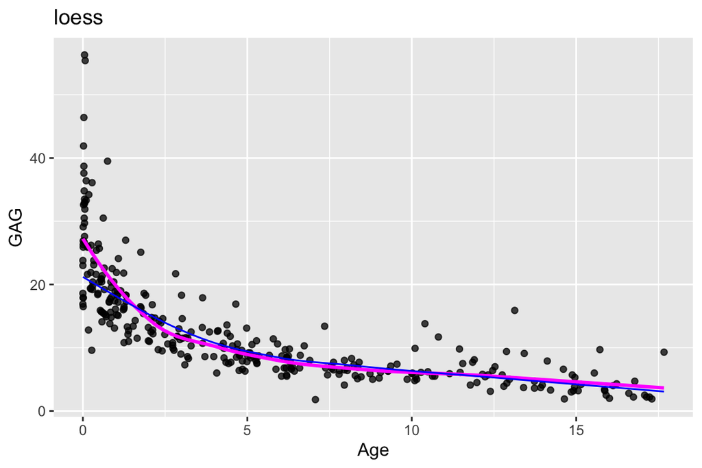

**Python**

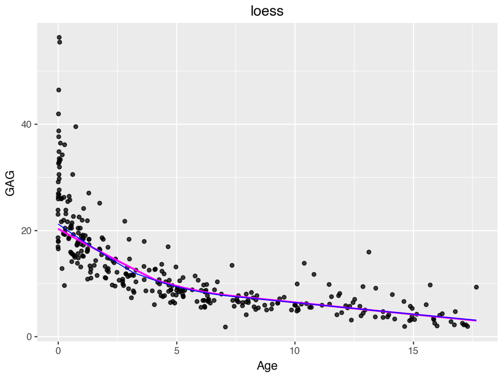

#### 커널 평활화

$$\widehat{y}_i=\sum_{j=1}^n y_i K\left(\frac{x_i-x_j}{b}\right) / \sum_{j=1}^n K\left(\frac{x_i-x_j}{b}\right)$$
- $b$: 대역폭, $K$: 커널 함수 (예: Gaussian)

**R**

```r
attach(GAGurine)
mypred1 <- as.data.frame(ksmooth(Age, GAG, "normal", bandwidth = 1))
names(mypred1) <- c("Age", "GAG")
mypred1$bandwidth <- "1"
mypred2 <- as.data.frame(ksmooth(Age, GAG, "normal", bandwidth = 5))
names(mypred2) <- c("Age", "GAG")
mypred2$bandwidth <- "5"
mypred <- rbind(mypred1, mypred2)
detach(GAGurine)
ggplot(GAGurine, aes(x=Age, y=GAG)) +
  geom_point(alpha=0.75) +
  geom_line(data=mypred, aes(x=Age, y=GAG, color=bandwidth)) +
  labs(title = "ksmooth")
```

**Python**

```python
from statsmodels.nonparametric.kernel_regression import KernelReg

xx = np.linspace(GAGurine['Age'].min(), GAGurine['Age'].max(), 200)

# 'c' indicates a continuous variable
kr1 = KernelReg(endog=GAGurine['GAG'], exog=GAGurine['Age'], var_type='c', bw=[1])
y_kr1, _ = kr1.fit(xx)
mypred1 = pd.DataFrame({'Age': xx, 'GAG': y_kr1, 'bandwidth': '1'})

kr5 = KernelReg(endog=GAGurine['GAG'], exog=GAGurine['Age'], var_type='c', bw=[5])
y_kr5, _ = kr5.fit(xx)
mypred2 = pd.DataFrame({'Age': xx, 'GAG': y_kr5, 'bandwidth': '5'})

mypred = pd.concat([mypred1, mypred2])
(
    ggplot(GAGurine, aes(x='Age', y='GAG'))
    + geom_point(alpha=0.75, size=0.75)
    + geom_line(data=mypred, mapping=aes(x='Age', y='GAG', color='bandwidth'))
    + labs(title="Kernel Smoothing (ksmooth equivalent)")
).show()
```

**R**

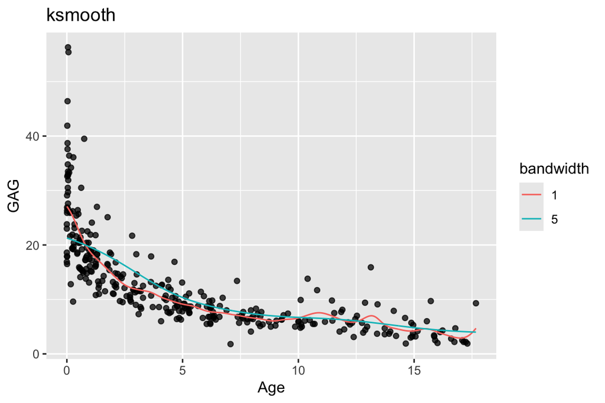

**Python**

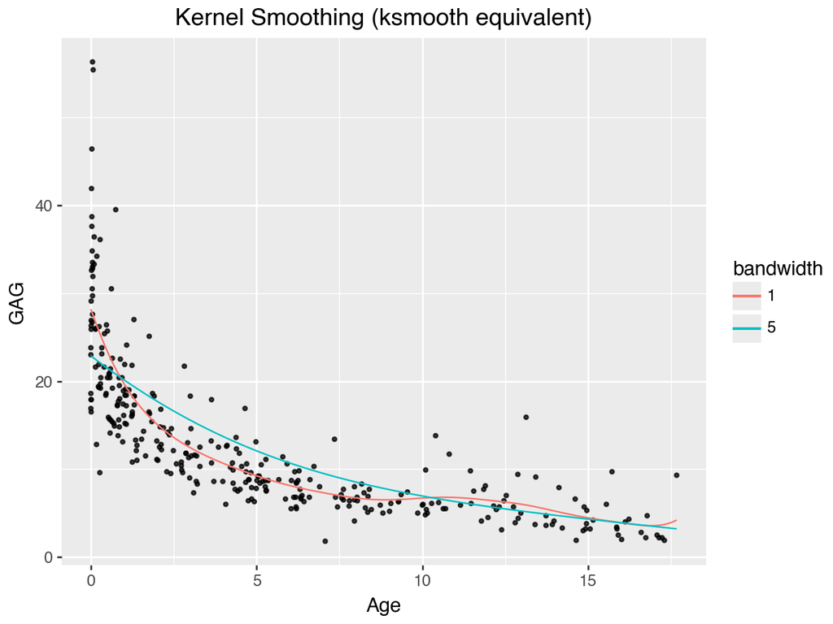

#### 국소 다항회귀

- 커널 회귀는 국소적으로 상수함수를 적합
- 다항함수(특히 홀수 차수)의 국소적 적합이 이론적 이점이 있음 (Wand and Jones, 1995)

**R**

```r
attach(GAGurine)
h <- KernSmooth::dpill(Age, GAG)  # bandwidth selection
mypred1 <- as.data.frame(KernSmooth::locpoly(Age, GAG, degree = 0, bandwidth = h))
names(mypred1) <- c("Age", "GAG")
mypred1$degree <- "0"
mypred2 <- as.data.frame(KernSmooth::locpoly(Age, GAG, degree = 1, bandwidth = h))
names(mypred2) <- c("Age", "GAG")
mypred2$degree <- "1"
mypred3 <- as.data.frame(KernSmooth::locpoly(Age, GAG, degree = 2, bandwidth = h))
names(mypred3) <- c("Age", "GAG")
mypred3$degree <- "2"
mypred <- rbind(mypred1, mypred2, mypred3)
detach(GAGurine)
ggplot(GAGurine, aes(x=Age, y=GAG)) +
  geom_point(alpha=0.75) +
  geom_line(data=mypred, aes(x=Age, y=GAG, color=degree)) +
  labs(title = "locpoly")
```

**Python**

```python
xx = np.linspace(GAGurine['Age'].min(), GAGurine['Age'].max(), 200)
# statsmodels uses the 'reg_type' parameter:
# 'lc' = local constant (degree 0)
# 'll' = local linear (degree 1)
# Note: For degree 2 (quadratic), statsmodels doesn't have a direct 'lq' string, so we'll focus on the primary ones or use an alternative.
results = []
for deg_label, reg_type in [("0", "lc"), ("1", "ll")]:
    kr = KernelReg(endog=GAGurine['GAG'], exog=GAGurine['Age'], var_type='c', reg_type=reg_type, bw=[0.5])
    y_fit, _ = kr.fit(xx)
    temp_df = pd.DataFrame({'Age': xx, 'GAG': y_fit, 'degree': deg_label})
    results.append(temp_df)

mypred = pd.concat(results)
(
    ggplot(GAGurine, aes(x='Age', y='GAG'))
    + geom_point(alpha=0.7)
    + geom_line(data=mypred, mapping=aes(x='Age', y='GAG', color='degree'))
    + labs(title="locpoly")
).show()
```

**R**

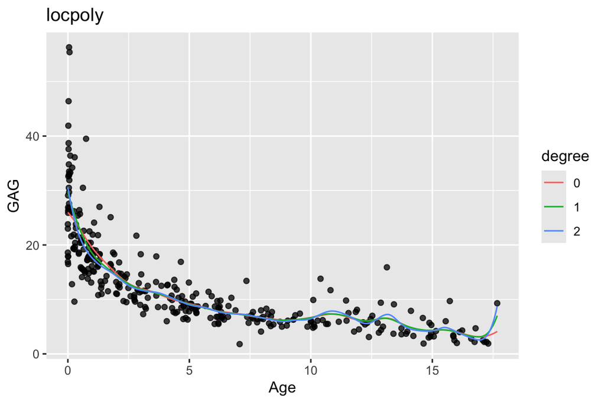

**Python**

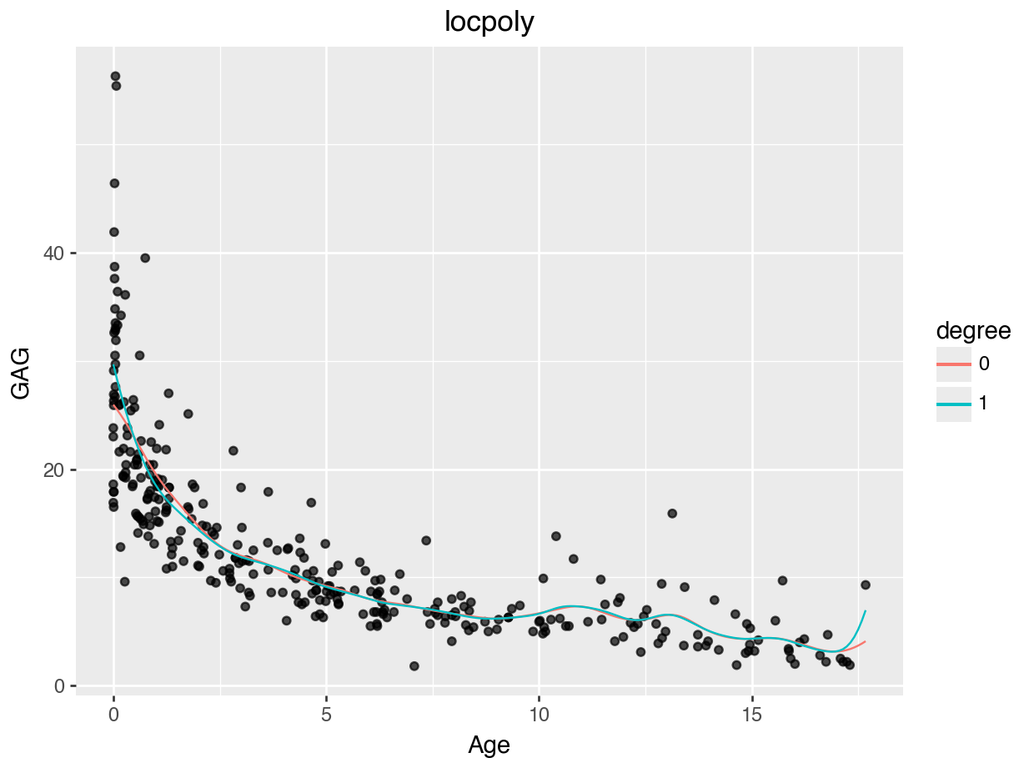

# 가법 모형

## 일반화 가법모형(generalized additive models, GAM)

- 선형회귀 모형
  $$Y=\alpha+\sum_{j=1}^p \beta_j X_j+\epsilon$$
- 가법 모형: $\beta_j X_j \gets f_j(X_j)$, $f_j: \mathbb{R}\to\mathbb{R}$:
  $$Y=\alpha+\underset{j=1} { \stackrel{p}{\sum} } f_j (X_j)+\epsilon$$
  - *임의의* 함수 $f_j$를 허용하는 것은 유용하지 않으므로 **평활함수**로 제약
  - 함수 $f_j$가 $\alpha$를 포함할 수 있음

## 역적합(backfitting)

- 잔차
  $$Y - \alpha - \sum_{k \ne j} f_k (X_k)$$
  에 대해 산점도 평활자를 이용, 평활함수 $f_j$르 적합
  - 모형의 선형 항들은 최소제곱법으로 적합
  - 수렴될 때까지 반복
- `gam::gam()`
  - 모형 공식은 평활 스플라인과 loess를 나타내는 `s(x)`, `lo(x)` 항을 허용

## `rock` 자료

- 석유를 함유한 암석 12개 각각의 4개 단면에 대한 측정값(`area`, `peri`, `shape`—암석 단면에 있는 기공의 원형도) 포함
- 목표: 다른 세 가지 측정값을 통해 투과성 `perm`(유체 흐름의 특성)을 예측
- 투과율의 스케일(6.3–1300)이 크게 변하므로 로그 척도 사용

**R**

```r
rock.lm <-  lm(log(perm) ~ area + peri + shape, data = rock)
rock.gam <- gam::gam(log(perm) ~ s(area) + s(peri) + s(shape),
                     control = gam::gam.control(maxit = 50),
                     data = rock)
summary(rock.gam)
```

```
Call: gam::gam(formula = log(perm) ~ s(area) + s(peri) + s(shape),
    data = rock, control = gam::gam.control(maxit = 50))
Deviance Residuals:
    Min      1Q  Median      3Q     Max
-1.6848 -0.4702  0.1235  0.5430  1.2955

(Dispersion Parameter for gaussian family taken to be 0.7446)

    Null Deviance: 126.9322 on 47 degrees of freedom
Residual Deviance: 26.0597 on 35.0005 degrees of freedom
AIC: 134.8981

Number of Local Scoring Iterations: NA

Anova for Parametric Effects
              Df Sum Sq Mean Sq  F value    Pr(>F)
s(area)    1.000 14.577  14.577  19.5788 8.988e-05 ***
s(peri)    1.000 75.670  75.670 101.6321 6.856e-12 ***
s(shape)   1.000  0.413   0.413   0.5548    0.4613
Residuals 35.001 26.060   0.745
---
Signif. codes:  0 '***' 0.001 '**' 0.01 '*' 0.05 '.' 0.1 ' ' 1

Anova for Nonparametric Effects
            Npar Df  Npar F  Pr(F)
(Intercept)
s(area)           3 0.34165 0.7953
s(peri)           3 0.94055 0.4315
s(shape)          3 1.43200 0.2500
```

**Python**

```python
from pygam import LinearGAM, s, f
from scipy.stats import chi2

df_rock = sm.datasets.get_rdataset("rock", "datasets").data

rock_lm = smf.ols('np.log(perm) ~ area + peri + shape', data=df_rock).fit()

# pygam requires the feature matrix (X) and target vector (y)
X = df_rock[['area', 'peri', 'shape']]
y = np.log(df_rock['perm'])
# s(0) corresponds to s(area), s(1) to s(peri), etc.
rock_gam = LinearGAM(s(0) + s(1) + s(2), max_iter=50).fit(X, y)

print(rock_lm.summary())
```

```
                            OLS Regression Results
==============================================================================
Dep. Variable:           np.log(perm)   R-squared:                       0.748
Model:                            OLS   Adj. R-squared:                  0.731
Method:                 Least Squares   F-statistic:                     43.60
Date:                Sun, 31 May 2026   Prob (F-statistic):           3.09e-13
Time:                        23:07:36   Log-Likelihood:                -58.339
No. Observations:                  48   AIC:                             124.7
Df Residuals:                      44   BIC:                             132.2
Df Model:                           3
Covariance Type:            nonrobust
==============================================================================
                 coef    std err          t      P>|t|      [0.025      0.975]
------------------------------------------------------------------------------
Intercept      5.3331      0.549      9.720      0.000       4.227       6.439
area           0.0005   8.66e-05      5.602      0.000       0.000       0.001
peri          -0.0015      0.000     -8.623      0.000      -0.002      -0.001
shape          1.7565      1.756      1.000      0.323      -1.782       5.295
==============================================================================
Omnibus:                        2.567   Durbin-Watson:                   0.672
Prob(Omnibus):                  0.277   Jarque-Bera (JB):                2.445
Skew:                          -0.503   Prob(JB):                        0.294
Kurtosis:                       2.541   Cond. No.                     1.20e+05
==============================================================================

Notes:
[1] Standard Errors assume that the covariance matrix of the errors is correctly specified.
[2] The condition number is large, 1.2e+05. This might indicate that there are
strong multicollinearity or other numerical problems.
```

```python
print(rock_gam.summary())
```

```
LinearGAM
=============================================== ==========================================================
Distribution:                        NormalDist Effective DoF:                                      15.708
Link Function:                     IdentityLink Log Likelihood:                                   -60.1401
Number of Samples:                           48 AIC:                                              153.6963
                                                AICc:                                             173.2306
                                                GCV:                                                2.2804
                                                Scale:                                              0.9976
                                                Pseudo R-Squared:                                   0.7468
==========================================================================================================
Feature Function                  Lambda               Rank         EDoF         P > x        Sig. Code
================================= ==================== ============ ============ ============ ============
s(0)                              [0.6]                20                        9.67e-05     ***
s(1)                              [0.6]                20                        4.48e-05     ***
s(2)                              [0.6]                20                        6.54e-04     ***
intercept                                              1                         0.00e+00     ***
==========================================================================================================
Significance codes:  0 '***' 0.001 '**' 0.01 '*' 0.05 '.' 0.1 ' ' 1

WARNING: Fitting splines and a linear function to a feature introduces a model identifiability problem
         which can cause p-values to appear significant when they are not.

WARNING: p-values calculated in this manner behave correctly for un-penalized models or models with
         known smoothing parameters, but when smoothing parameters have been estimated, the p-values
         are typically lower than they should be, meaning that the tests reject the null too readily.
None
```

```r
anova(rock.lm,  rock.gam)
```

```
Analysis of Variance Table

Model 1: log(perm) ~ area + peri + shape
Model 2: log(perm) ~ s(area) + s(peri) + s(shape)
  Res.Df    RSS     Df Sum of Sq      F Pr(>F)
1 44.000 31.949
2 35.001 26.060 8.9995    5.8891 0.8789 0.5528
```

**R**

```r
rock.gam1 <- gam::gam(log(perm) ~ area + peri + s(shape), data = rock)
anova(rock.lm,  rock.gam1,  rock.gam)
```

```
Analysis of Variance Table

Model 1: log(perm) ~ area + peri + shape
Model 2: log(perm) ~ area + peri + s(shape)
Model 3: log(perm) ~ s(area) + s(peri) + s(shape)
  Res.Df    RSS     Df Sum of Sq      F Pr(>F)
1 44.000 31.949
2 41.000 28.999 3.0000    2.9495 1.3205 0.2833
3 35.001 26.060 5.9995    2.9396 0.6581 0.6835
```

**Python**

```python
from pygam import LinearGAM, l, s

X = df_rock[['area', 'peri', 'shape']]
y = np.log(df_rock['perm'])

# l() is the linear term in pygam
rock_gam1 = LinearGAM(l(0) + l(1) + s(2)).fit(X, y)

## extract RSS and DF
def get_metrics(model, y_true, X_input, is_statsmodels=False):
    if is_statsmodels:
        y_pred = model.predict()
        df_resid = model.df_resid
    else:
        y_pred = model.predict(X_input)
        # EDOF = Effective Degrees of Freedom
        df_resid = len(y_true) - model.statistics_['edof']

    rss = np.sum((y_true - y_pred)**2)
    return rss, df_resid

rss_lm, df_lm = get_metrics(rock_lm, y, X, is_statsmodels=True)
rss_g1, df_g1 = get_metrics(rock_gam1, y, X)
rss_g,  df_g  = get_metrics(rock_gam, y, X)

results = pd.DataFrame({
    "Model": ["LM", "GAM1 (Semi)", "GAM (Full)"],
    "Resid. DF": [df_lm, df_g1, df_g],
    "RSS": [rss_lm, rss_g1, rss_g]
})
results["Df_Diff"] = results["Resid. DF"].diff() * -1
results["Sum_Sq"] = results["RSS"].diff() * -1
print(results)
```

```
         Model  Resid. DF        RSS   Df_Diff    Sum_Sq
0           LM  44.000000  31.948772       NaN       NaN
1  GAM1 (Semi)  37.861240  26.209891  6.138760  5.738881
2   GAM (Full)  32.291977  32.137731  5.569263 -5.927841
```

- 결과는 각 일변수함수가 하나의 선형 자유도와 세 개의 비선형 자유도를 가짐을 보여준다.
- RSS를 31.95(선형 적합)에서 26.06(완전비선형적합)으로 줄이는 것은 추가 자유도 9에서는 유의하지 않음
- `peri`에 대한 비선형 항은 유의하지 않아 보임
  - `shape`의 비선형 항만으로 RSS는 29.00

**R**

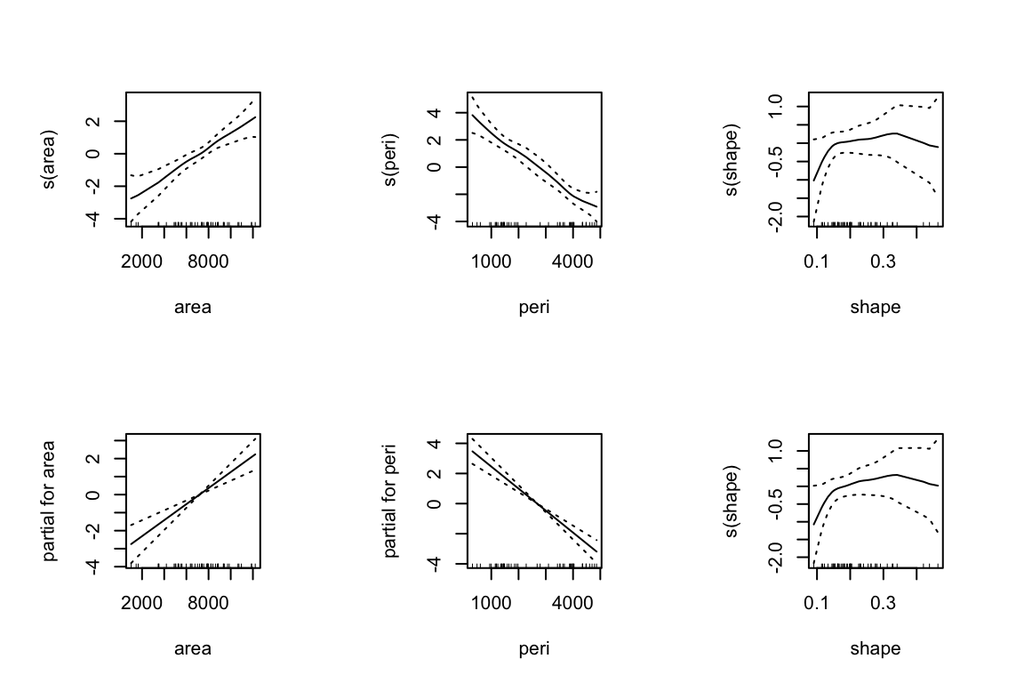

```r
par(mfrow =  c(2, 3), pty = "s")
plot(rock.gam,  se = T)
plot(rock.gam1,  se = T)
```

**Python**

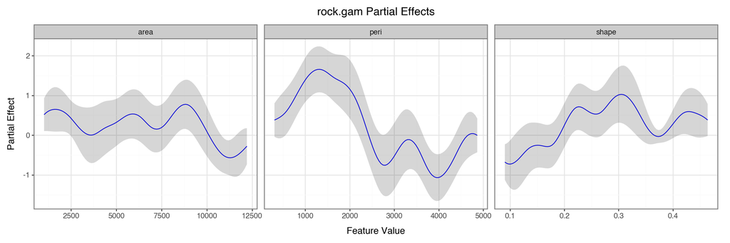

```python
def get_gam_plots(model, feature_names):
    plot_data = []
    for i, name in enumerate(feature_names):
        # Generate a grid for the specific feature
        XX = model.generate_X_grid(term=i)

        # Get partial dependence and confidence intervals
        pdep, confi = model.partial_dependence(term=i, X=XX, width=0.95)

        df = pd.DataFrame({
            'x': XX[:, i],
            'y': pdep,
            'y_low': confi[:, 0],
            'y_high': confi[:, 1],
            'feature': name
        })
        plot_data.append(df)
    return pd.concat(plot_data)

data_gam = get_gam_plots(rock_gam, ['area', 'peri', 'shape'])
data_gam1 = get_gam_plots(rock_gam1, ['area', 'peri', 'shape'])

plot_gam = (
    ggplot(data_gam, aes(x='x', y='y'))
    + geom_line(color='blue')
    + geom_ribbon(aes(ymin='y_low', ymax='y_high'), alpha=0.2)
    + facet_wrap('~feature', scales='free_x')
    + labs(title="rock.gam Partial Effects", x="Feature Value", y="Partial Effect")
    + theme_bw()
    + theme(figure_size=(12, 4))
)
# 3. Plotting rock.gam1 partial effects
plot_gam1 = (
    ggplot(data_gam1, aes(x='x', y='y'))
    + geom_line(color='red')
    + geom_ribbon(aes(ymin='y_low', ymax='y_high'), alpha=0.2)
    + facet_wrap('~feature', scales='free_x')
    + labs(title="rock.gam1 Partial Effects", x="Feature Value", y="Partial Effect")
    + theme_bw()
    + theme(figure_size=(12, 4))
)

plot_gam.show()
```

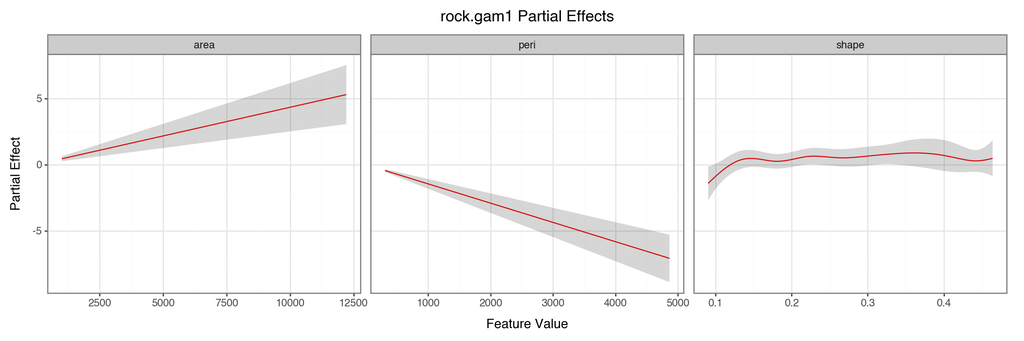

```python
plot_gam1.show()
```

- 평활함수 중 하나만 비선형으로 나타나고 이조차 완전히 설득력이 있는 것도 아니다.

### `mgcv::gam()`

- `gam::gam()` 사용시 가장 큰 어려움 중 하나는 각 항의 평활화 정도를 정하는 것
  - `s()`의 경우 기본 자유도는 4, `lo()`의 경우 `f=0.5`
- `mgcv::gam()`에서는 평활화 정도가 적합의 일부로 추정([Wood, Pya, & Saefken, 2016](https://doi.org/10.1080/01621459.2016.1180986))

```r
mgcv::gam(log(perm) ~ s(area) + s(peri) + s(shape), data=rock)
```

```
Family: gaussian
Link function: identity

Formula:
log(perm) ~ s(area) + s(peri) + s(shape)

Estimated degrees of freedom:
1.0 1.0 1.4  total = 4.4

GCV score: 0.7886465
```

## 다중 가법 회귀 스플라인(MARS, [Friedman, 1991](https://doi.org/10.1214/aos/1176347963))

- 기본값으로 선형 스플라인(조각 연속 1차 함수)을 각 변수에 적합하는 가법 모형
  - 고차 교호작용 허용
- 조각의 수는 소프트웨어적으로 선택

### `cpus` 자료

```r
head(MASS::cpus)
```

```
            name syct mmin  mmax cach chmin chmax perf estperf
1  ADVISOR 32/60  125  256  6000  256    16   128  198     199
2  AMDAHL 470V/7   29 8000 32000   32     8    32  269     253
3  AMDAHL 470/7A   29 8000 32000   32     8    32  220     253
4 AMDAHL 470V/7B   29 8000 32000   32     8    32  172     253
5 AMDAHL 470V/7C   29 8000 16000   32     8    16  132     132
6  AMDAHL 470V/8   26 8000 32000   64     8    32  318     290
```

- 미니컴퓨터와 메인프레임의 혼합 벤치마크 성능에 대한 연구(Ein-Dor and Feldmesser, 1987)
- `syst`: 사이클 시간(나노초), `cach`: 캐시 크기(KB), `mmin`, `mmax`: 메인 메모리 크기(KB), `chmin`, `chmax`: 채널 수
  - 측정값은 IBM 370/158-3을 기준으로 정규화
- 선형모형(교재 6.9절)

```r
set.seed(123)
cpus2 <- select(cpus, -c(name, estperf)) # excludes names, authors' predictions
cpus.samp <- sample(seq_len(nrow(cpus2)), 100)
cpus.lm <- lm(log10(perf)~., data=cpus2 |>
                              dplyr::slice(cpus.samp) )
cpus.lm2 <- stepAIC(cpus.lm, trace=FALSE)
test.cpus <- function(fit)
  sqrt(sum((log10(cpus2 |> slice(-cpus.samp) |> select(perf)) -
            predict(fit, cpus2 |> slice(-cpus.samp)))^2)/109)
test.cpus(cpus.lm)
```

```
[1] 0.2270138
```

```r
cpus.lm2 <- stepAIC(cpus.lm, trace=FALSE)
cpus.lm2$anova
```

```
Stepwise Model Path
Analysis of Deviance Table

Initial Model:
log10(perf) ~ syct + mmin + mmax + cach + chmin + chmax

Final Model:
log10(perf) ~ syct + mmin + mmax + cach

     Step Df    Deviance Resid. Df Resid. Dev       AIC
1                               93   2.936109 -338.8085
2 - chmax  1 0.001168625        94   2.937277 -340.7687
3 - chmin  1 0.042380328        95   2.979658 -341.3362
```

```r
test.cpus(cpus.lm2)
```

```
[1] 0.2273272
```

- 따라서 더 작은 모델을 선택한다고 해서 예측성능이 향상되지는 않음
- 선형스플라인 가법모형 (역적합과 다른 방식으로 적합):

```r
Xin <- as.matrix(cpus2 |> dplyr::slice(cpus.samp) |> select(-perf) )
cpus.mars <- mda::mars(Xin, log10(cpus2 |> slice(cpus.samp) |> select(perf) ))
test2 <- function(fit) {  # test error
    Xp <- as.matrix(cpus2 |> slice(-cpus.samp) |> select(-perf) ) #cpus2[-cpus.samp,  1:6])
    sqrt(sum((log10(cpus2 |> slice(-cpus.samp) |> select(perf) ) - predict(fit, Xp))^2)/109)
}
test2(cpus.mars)
```

```
[1] 0.2064594
```

```r
showcuts <- function(obj) {
    tmp  <-  obj$cuts[obj$sel, ]
    dimnames(tmp)  <- list(NULL,  colnames(Xin))
    tmp
}
showcuts(cpus.mars)
```

```
     syct mmin  mmax cach chmin chmax
[1,]    0    0     0    0     0     0
[2,]    0    0 20970    0     0     0
[3,]    0    0     0   30     0     0
[4,]    0    0     0   30     0     0
[5,]    0 1500     0    0     0     0
[6,]    0    0     0    0     0    38
[7,]    0    0     0    0     0    38
[8,]  124    0     0    0     0     0
```

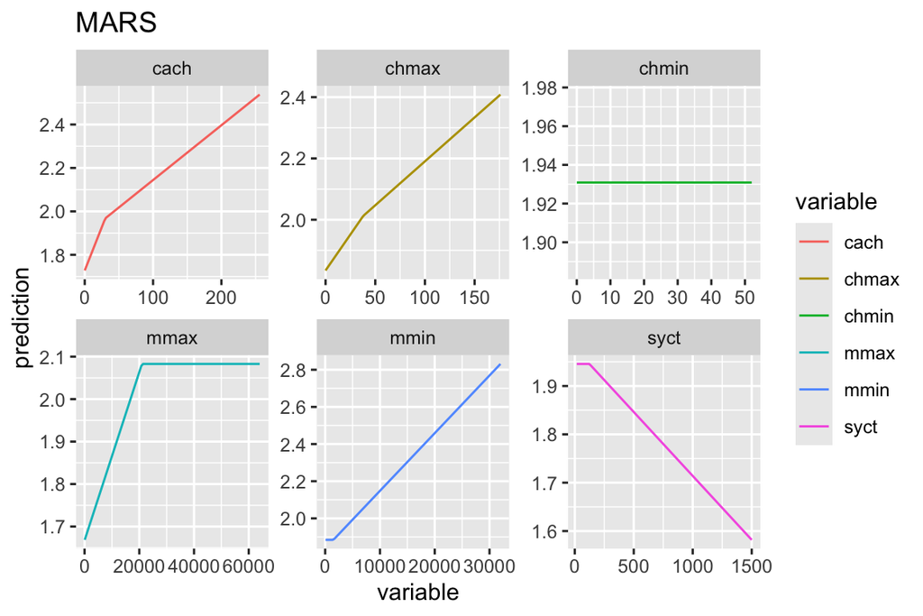

```r
# examine the fitted functions
Xp <- matrix(cpus2 |> slice(cpus.samp) |> select(-perf) |> map_dbl(mean),
             100, 6, byrow = T)
xr <- sapply(cpus2, range) # variable ranges
df_plt <- list()
for (i in seq_len(ncol(Xp))) {
    Xp1 <- Xp  # hold other variables
    xvals <- seq(xr[1, i], xr[2, i], len = 100)
    Xp1[, i] <- xvals
    df_plt[[i]] <- data.frame(x = xvals, y = predict(cpus.mars, Xp1),
                              variable = names(cpus2)[i])
}
df_long <- dplyr::bind_rows(df_plt)
ggplot(df_long, aes(x = x, y = y, color = variable)) + geom_line() +
  facet_wrap(~ variable, ncol = 3, scales = "free")
```

```r
## allow pairwise interaction terms
cpus.mars2 <- mars(Xin, log10(cpus2 |> slice(cpus.samp) |> select(perf) ), degree = 2)
showcuts(cpus.mars2)
```

```
      syct mmin  mmax cach chmin chmax
 [1,]    0    0     0    0     0     0
 [2,]    0    0 20970    0     0     0
 [3,]    0    0 20970    0     0     0
 [4,]    0    0 20970    6     0     0
 [5,]    0    0 20970    6     0     0
 [6,]    0 2620     0    0     0     0
 [7,]    0    0     0    0     5     0
 [8,]  185 2620     0    0     0     0
 [9,]    0    0 20970    0     0    38
```

```r
test2(cpus.mars2)
```

```
[1] 0.231812
```

```r
## allow arbitrary interactions
cpus.mars6 <- mars(Xin, log10(cpus2 |> slice(cpus.samp) |> select(perf) ), degree = 6)
showcuts(cpus.mars6)
```

```
      syct mmin  mmax cach chmin chmax
 [1,]    0    0     0    0     0     0
 [2,]    0    0 20970    0     0     0
 [3,]    0    0 20970    0     0     0
 [4,]    0    0 20970    6     0     0
 [5,]    0 2620     0    0     0     0
 [6,]    0    0     0    0     5     0
 [7,]  185 2620     0    0     0     0
 [8,]  200    0 20970    6     0     0
 [9,]  160    0 20970    6     0     0
[10,]  185 2620  6300    0     0     0
```

```r
test2(cpus.mars6)
```

```
[1] 0.2198926
```

- 조각별 교호작용 항(`degree=2`)이나 임의의 교호작용(`degree=6`)을 허용하는 것은 예측의 효율성에 거의 차이가 없다.

# 사영 추적 회귀

## 사영 추적 회귀모형 ([Friedman and Stuetzle, 1981](https://doi.org/10.2307/2287576))

$$Y = \alpha_0 + \sum_{j=1}^{M} f_j (\boldsymbol{\alpha}_j^T \boldsymbol{X}) + \epsilon
, \quad
\|\boldsymbol{\alpha}_j\| = 1$$

## `stats::ppr()`

- 최소제곱법으로 사영 추적 회귀모형 적합
  1. $M_{\max}$개 항을 순차적으로 적합
  2. 각 단계에서 가장 효과가 작은 항 제거
  3. 항이 $M$ 개가 될 때까지 재적합
- $M,..., M_{max}$ 항 모형들의 RSS 반환
- $f_j$: Friedman’s supersmoother (`supsmu`), 평활스플라인

### `rock` 자료

```r
rock1 <- rock |> dplyr::mutate(area = area / 10000, peri = peri / 10000)
(rock.ppr <- ppr(log(perm) ~ area + peri + shape,
                 data = rock1, nterms = 2, max.terms = 5))
```

```
Call:
ppr(formula = log(perm) ~ area + peri + shape, data = rock1,
    nterms = 2, max.terms = 5)

Goodness of fit:
 2 terms  3 terms  4 terms  5 terms
8.737806 5.289517 4.745799 4.490378
```

```r
summary(rock.ppr)
```

```
Call:
ppr(formula = log(perm) ~ area + peri + shape, data = rock1,
    nterms = 2, max.terms = 5)

Goodness of fit:
 2 terms  3 terms  4 terms  5 terms
8.737806 5.289517 4.745799 4.490378

Projection direction vectors ('alpha'):
      term 1      term 2
area   0.34357179  0.37071027
peri  -0.93781471 -0.61923542
shape  0.04961846  0.69218595

Coefficients of ridge terms ('beta'):
   term 1    term 2
1.6079271 0.5460971
```

- 모형
  $$Y_i = \alpha_{i0} + \sum_{j=1}^{M} \beta_{ij} f_j (\boldsymbol{\alpha}_j^T \boldsymbol{X}) + \epsilon$$
  - $\beta_{ij}$: 다중 응답 회귀 모형에 대응
  - 능형함수 $f_j$는 자료의 사영에 대해 평균 0 및 분산 1이 되도록 스케일링

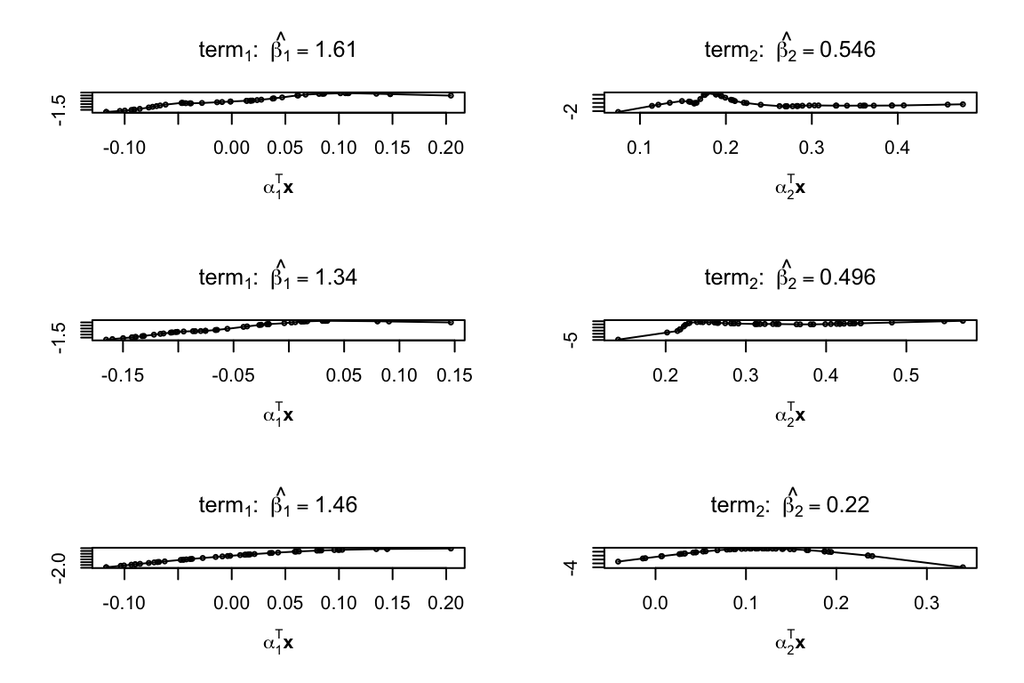

```r
par(mfrow = c(3,  2))
plot(rock.ppr)
plot(update(rock.ppr,  bass = 5)) # supsmu control
# use smoothing spline with GCV
plot(rock.ppr2 <- update(rock.ppr,  sm.method = "gcvspline", gcvpen = 2))
```

```r
summary(rock.ppr2)
```

```
Call:
ppr(formula = log(perm) ~ area + peri + shape, data = rock1,
    nterms = 2, max.terms = 5, sm.method = "gcvspline", gcvpen = 2)

Goodness of fit:
 2 terms  3 terms  4 terms  5 terms
22.46665 21.32422 21.32419 21.32405

Projection direction vectors ('alpha'):
      term 1      term 2
area   0.34852171  0.51414309
peri  -0.93698661 -0.83965221
shape  0.02426324 -0.17504585

Coefficients of ridge terms ('beta'):
   term 1    term 2
1.4647599 0.2202937

Equivalent df for ridge terms:
term 1 term 2
  2.83   2.00
```

- 2항 모형이 효과적인 것으로 보이고, `area`, `peri`가 지배적

### 능형함수 시각화

```r
summary(rock1) # to find the ranges of the variables
```

```
      area             peri             shape              perm
 Min.   :0.1016   Min.   :0.03086   Min.   :0.09033   Min.   :   6.30
 1st Qu.:0.5305   1st Qu.:0.14149   1st Qu.:0.16226   1st Qu.:  76.45
 Median :0.7487   Median :0.25362   Median :0.19886   Median : 130.50
 Mean   :0.7188   Mean   :0.26822   Mean   :0.21811   Mean   : 415.45
 3rd Qu.:0.8870   3rd Qu.:0.39895   3rd Qu.:0.26267   3rd Qu.: 777.50
 Max.   :1.2212   Max.   :0.48642   Max.   :0.46413   Max.   :1300.00
```

```r
Xp  <- expand.grid(area = seq(0.1, 1.2, 0.05), peri = seq(0, 0.5, 0.02),
                   shape = 0.2)
rock.grid <- cbind(Xp, fit = predict(rock.ppr2, Xp))
lattice::wireframe(fit ~ area +  peri, rock.grid,
                   screen = list(z = 160,  x = -60),
                   aspect = c(1,  0.5), drape = T)
```

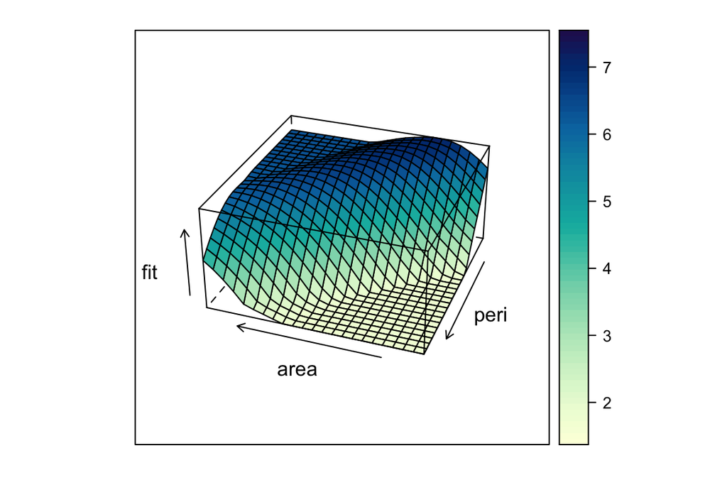

## 예제: `cpus` 자료

### `supsmu`

```r
(cpus.ppr <- ppr(log10(perf)~., data = cpus2 |> dplyr::slice(cpus.samp),
                 nterms = 2, max.terms = 10, bass = 5))
```

```
Call:
ppr(formula = log10(perf) ~ ., data = dplyr::slice(cpus2, cpus.samp),
    nterms = 2, max.terms = 10, bass = 5)

Goodness of fit:
 2 terms  3 terms  4 terms  5 terms  6 terms  7 terms  8 terms  9 terms
2.000989 1.729778 1.726409 1.416302 1.295887 1.075994 1.111010 1.040365
10 terms
1.178248
```

```r
cpus.ppr <- ppr(log10(perf)~., data = cpus2 |> dplyr::slice(cpus.samp),
                nterms = 8, max.terms = 10, bass = 5)  # select 8 terms
test.cpus(cpus.ppr)
```

```
[1] 0.2197131
```

### `spline`

```r
ppr(log10(perf)~., data = cpus2 |> dplyr::slice(cpus.samp),
    nterms = 2, max.terms = 10, sm.method = "spline")
```

```
Call:
ppr(formula = log10(perf) ~ ., data = dplyr::slice(cpus2, cpus.samp),
    nterms = 2, max.terms = 10, sm.method = "spline")

Goodness of fit:
 2 terms  3 terms  4 terms  5 terms  6 terms  7 terms  8 terms  9 terms
2.143237 1.817936 1.680882 1.488281 1.440373 1.323631 1.298970 1.301668
10 terms
1.241848
```

```r
cpus.ppr2 <- ppr(log10(perf)~., data = cpus2 |> dplyr::slice(cpus.samp),
                 nterms = 7,  max.terms = 10, sm.method = "spline")
test.cpus(cpus.ppr2)
```

```
[1] 0.2179952
```

- 예측값 비교

```r
res3 <- unlist(log10(cpus2 |> dplyr::slice(-cpus.samp) |> select(perf)) -
                  predict(cpus.ppr, cpus2 |> dplyr::slice(-cpus.samp)) )
res2 <- unlist(log10(cpus2 |> slice(-cpus.samp) |> select(perf)) -
                  predict(cpus.lm2, cpus2 |> slice(-cpus.samp)))  # lm
wilcox.test(res2^2, res3^2, paired = T, alternative = "greater")
```

```
    Wilcoxon signed rank test with continuity correction

data:  res2^2 and res3^2
V = 3313, p-value = 0.1705
alternative hypothesis: true location shift is greater than 0
```

# 신경망

## 인공신경망

- 순방향(feed-forward) 신경망은 선형 회귀 함수를 유연하게 일반화 (Bishop, 1995; Ripley, 1996; [Goodfellow, Bengio, and Courville, 2016](https://www.deeplearningbook.org)).
- 모수가 너무 많은(overparameterized) 비선형 회귀 모형
- 단일 은닉층 순방향 신경망:
  $$y_k = \phi_o \left( \alpha_k+\sum_h w_{hk}\phi_h \left( \alpha_h+\sum_i w_{ih}x_i \right) \right)$$
  - $\phi_h$: 은닉층 단위의 활성화 함수. 로지스틱 함수 $\ell(z) = \frac{e^z}{1+e^z}$ 또는 ReLU $\ell(z) = (z)_{+}$.
  - $\phi_o$: 출력 단위의 활성화 함수. 선형, 로지스틱 또는 임계값 함수($\phi_o(x)=I(x>0)$).
    - 선형 출력함수의 경우 사영 추적 회귀의 특수한 경우
- 층 건너뛰기(skip-layer, skip-connection)
  $$y_k = \phi_o \left( \alpha_k+\sum_{i \rightarrow k} w_{ik}x_i + \sum_{j \rightarrow k} w_{jk}\phi_h \left( \alpha_j+\sum_{i \rightarrow j} w_{ij}x_i \right) \right)$$
- 모수: $\{\alpha_j\}$ (biases), $\{w_{jk}\}$ (weights)
- 선형 출력함수의 경우 은닉층의 크기를 늘리면 옹골집합에서 모든 연속 함수를 균일하게 근사 (Cybenko, 1989; Hornik, Stinchcombe and White, 1989)
- 근사 결과는 비건설적: 실제로는 적합 기준 (오차제곱합, 소프트맥스 등)을 최소화하도록 가중치를 선택
  $$\small
  E=\underset{p}{\sum} || t^p - y^p ||^2
  , \quad
  E=\sum_{p}\sum_{k}-t_k^p \log p_k^p, \quad p_k^p=\frac{e^{y_k^p}}{\sum_{c=1}^K e^{y_c^p}}$$
  - $t^p$는 타겟, $y^p$는 $p$번째 예제 패턴의 출력값
- 조절(regularization): $E+\lambda C(f)$, $f$ 회귀함수
  - 모형의 자유도 제약, 과적합 방지
  - Weight decay: $C(f) = \sum_{i,j} w_{ij}^2$ (입력이 $[0, 1]$ 범위로 조정되는 경우)
  - 참고: 드롭아웃

### `nnet::nnet()`

```r
nnet(formula, data, weights, size, Wts, linout = F, entropy = F,
    softmax = F, skip = F, rang = 0.7, decay = 0, maxit = 100,
    trace = T)
```

- 인수
  - `size`: 은닉층 단위의 개수
  - `Wts`: $w_{ij}$ 초기값
  - `linout`: 선형 출력함수?
  - `entropy`: 최소제곱 적합이 아닌 엔트로피 적합?
  - `softmax`: 소프트맥스 적합 (분류 문제)?
  - `skip`: 건너뛰기 허용?
  - `rang`: `Wts`가 누락된 경우 `runif(n,-rang, rang)`의 임의의 가중치를 사용한다.
  - `decay`: 가중치붕괴 모수 $\lambda$
  - `maxit`: 최적화에 대한 최대 반복 횟수
  - `Hess`: 해의 헤시안 행렬이 반환되어야 하는가?
  - `trace`: 적합과정 출력?

### `rock` 자료

**R**

```r
rock1 <- rock |> dplyr::mutate(area = area / 10000, peri = peri / 10000)
rock.nn <- nnet::nnet(log(perm) ~ area + peri + shape, data = rock1,
                      size = 3, decay = 1e-3, linout = T,  skip = T,
                      maxit = 1000, Hess = T)
```

**Python**

```python
from sklearn.neural_network import MLPRegressor

rock1 = df_rock.copy()
rock1['area'] = rock1['area'] / 10000
rock1['peri'] = rock1['peri'] / 10000

X = rock1[['area', 'peri', 'shape']]
y = np.log(rock1['perm'])

# solver='lbfgs' is recommended for small datasets like 'rock'
rock_nn = MLPRegressor(
    hidden_layer_sizes=(3,),
    activation='tanh',       # nnet uses sigmoid/logistic by default, tanh is similar
    solver='lbfgs',          # Better for small n (N=48 for rock)
    alpha=1e-3,              # Equivalent to 'decay'
    max_iter=1000,
    random_state=123
)
rock_nn.fit(X, y)
```

```
MLPRegressor(activation='tanh', alpha=0.001, hidden_layer_sizes=(3,),
             max_iter=1000, random_state=123, solver='lbfgs')
```

```python
print(f"R-squared: {rock_nn.score(X, y):.4f}")
```

```
R-squared: 0.9123
```

```python
print(f"Iterations: {rock_nn.n_iter_}")
```

```
Iterations: 738
```

**R**

```r
summary(rock.nn)
```

```
a 3-3-1 network with 19 weights
options were - skip-layer connections  linear output units  decay=0.001
 b->h1 i1->h1 i2->h1 i3->h1
 -8.90  15.51 -20.93  21.89
 b->h2 i1->h2 i2->h2 i3->h2
 -4.34  11.39 -16.54   8.39
 b->h3 i1->h3 i2->h3 i3->h3
 -2.09  11.08  -1.25   4.02
  b->o  h1->o  h2->o  h3->o  i1->o  i2->o  i3->o
  8.21  -8.51  15.32  -5.77  -2.52  -3.26   1.04
```

```r
sum((log(rock$perm) - predict(rock.nn))^2)
```

```
[1] 10.48597
```

```r
eigen(rock.nn$Hessian, T)$values
```

```
 [1] 1.355083e+03 1.148118e+02 5.301434e+01 1.778798e+01 5.027399e+00
 [6] 3.986997e+00 1.401615e+00 9.460983e-01 4.442903e-01 2.583381e-01
[11] 1.307680e-01 5.032033e-02 2.618249e-02 1.299301e-02 8.320477e-03
[16] 5.612390e-03 5.425800e-03 4.440746e-03 2.572032e-04
```

**Python**

```python
for i, (w, b) in enumerate(zip(rock_nn.coefs_, rock_nn.intercepts_)):
    print(f"\nLayer {i} to {i+1}:")
    print(f"Weights:\n{w}")
    print(f"Biases: {b}")
```

```
Layer 0 to 1:
Weights:
[[ 6.41152462  7.86243068 -7.26807532]
 [-9.02151898 10.91108073  0.94595424]
 [-2.78512747 -6.30399679  4.61893742]]
Biases: [-0.0260899  -8.67991666  0.89400805]

Layer 1 to 2:
Weights:
[[ 8.35992044]
 [-1.17357658]
 [ 5.74894461]]
Biases: [3.19815048]
```

```python
predictions = rock_nn.predict(X)
rss_nn = np.sum((y - predictions)**2)
print(f"\nResidual Sum of Squares (RSS): {rss_nn:.6f}")
```

```
Residual Sum of Squares (RSS): 11.130579
```

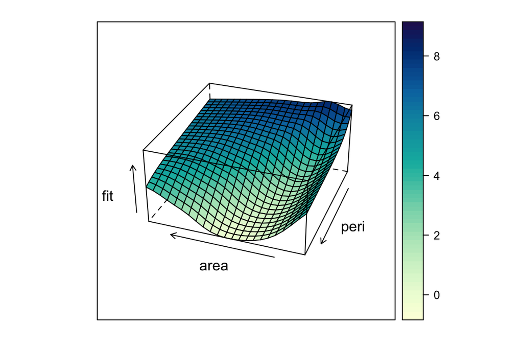

### 예제 : 자료 `cpus`

- 신경망 모형을 효과적으로 사용하려면 변수를 스케일하는 것이 필수적

**R**

```r
attach(cpus2)
cpus3 <- data.frame(syct = syct - 2, mmin = mmin - 3, mmax = mmax - 4,
                    cach = cach / 256,  chmin = chmin / 100,
                    chmax = chmax / 100, perf = perf)
detach(cpus2)
test.cpus <-  function(fit) {
    sqrt(sum((log10(cpus3 |> slice(-cpus.samp) |> select(perf)) -
              predict(fit, cpus3 |> slice(-cpus.samp)))^2)/109)
}
cpus.nn1 <- nnet(log10(perf)~., cpus3 |> slice(cpus.samp), linout = T,
                 skip = T,  size = 0) # linear model
test.cpus(cpus.nn1)
```

```
[1] 0.2270138
```

**Python**

```python
from sklearn.linear_model import LinearRegression

cpus = sm.datasets.get_rdataset("cpus", "MASS").data
cpus2 = cpus.drop(columns=['name', 'estperf'])
np.random.seed(123)
train_indices = np.random.choice(cpus2.index, 100, replace=False)
train_data = cpus2.loc[train_indices]
test_data = cpus2.drop(train_indices)

cpus3 = pd.DataFrame({
    'syct':  cpus2['syct'] - 2,
    'mmin':  cpus2['mmin'] - 3,
    'mmax':  cpus2['mmax'] - 4,
    'cach':  cpus2['cach'] / 256,
    'chmin': cpus2['chmin'] / 100,
    'chmax': cpus2['chmax'] / 100,
    'perf':  cpus2['perf']
})

train_data = cpus3.loc[train_indices]
test_data = cpus3.drop(train_indices)

X_train = train_data.drop(columns=['perf'])
y_train = np.log10(train_data['perf'])

cpus_nn1 = LinearRegression()
cpus_nn1.fit(X_train, y_train)
```

```
LinearRegression()
```

```python
def test_cpus_nn(fit, df_test):
    X_test = df_test.drop(columns=['perf'])
    y_test = np.log10(df_test['perf'])

    predictions = fit.predict(X_test)
    # The divisor 109 comes from the test set size
    rmse = np.sqrt(np.sum((y_test - predictions)**2) / 109)
    return rmse

print(f"RMSE (Size 0 / Linear): {test_cpus_nn(cpus_nn1, test_data):.4f}")
```

```
RMSE (Size 0 / Linear): 0.1857
```

- 비선형성(은닉층) 도입

**R**

```r
cpus.nn2 <- nnet(log10(perf)~., cpus3 |> slice(cpus.samp), linout = T,
                 skip=T, size=4, decay=0.01, maxit = 1000, trace=F)
test.cpus(cpus.nn2)
```

```
[1] 0.2169149
```

```r
cpus.nn3 <- nnet(log10(perf)~., cpus3 |> slice(cpus.samp), linout = T,
                 skip=T, size=10, decay=0.01, maxit = 1000, trace=F)
test.cpus(cpus.nn3)
```

```
[1] 0.2659701
```

```r
cpus.nn4 <- nnet(log10(perf)~., cpus3 |> slice(cpus.samp), linout = T,
                 skip=T, size=25, decay=0.01, maxit = 1000, trace=F)
test.cpus(cpus.nn4)
```

```
[1] 0.2923515
```

**Python**

```python
from sklearn.neural_network import MLPRegressor

def fit_and_test_nn(size, decay, X_train, y_train, X_test, y_test):
    nn = MLPRegressor(
        hidden_layer_sizes=(size,),
        activation='logistic',  # nnet uses sigmoid/logistic
        solver='lbfgs',         # better for small datasets like cpus
        alpha=decay,            # L2 regularization
        max_iter=1000,
        random_state=123        # For reproducibility
    )

    nn.fit(X_train, y_train)

    predictions = nn.predict(X_test)
    rmse = np.sqrt(np.sum((y_test - predictions)**2) / 109)
    return rmse

X_train = train_data.drop(columns=['perf'])
y_train = np.log10(train_data['perf'])
X_test = test_data.drop(columns=['perf'])
y_test = np.log10(test_data['perf'])

rmse2 = fit_and_test_nn(4, 0.01, X_train, y_train, X_test, y_test)
rmse3 = fit_and_test_nn(10, 0.01, X_train, y_train, X_test, y_test)
rmse4 = fit_and_test_nn(25, 0.01, X_train, y_train, X_test, y_test)

print(f"Size  4 RMSE: {rmse2:.4f}")
```

```
Size  4 RMSE: 0.4489
```

```python
print(f"Size 10 RMSE: {rmse3:.4f}")
```

```
Size 10 RMSE: 0.4538
```

```python
print(f"Size 25 RMSE: {rmse4:.4f}")
```

```
Size 25 RMSE: 0.3654
```

### 교차검증에 의한 가중치 붕괴 선택

**R**

```r
CVnn.cpus <- function(formula, data = cpus3,
    size = c(0, 4, 4, 10, 10),
    lambda = c(0, rep(c(0.003, 0.01), 2)),
    nreps = 5, nifold = 10, ...) {
  CVnn1 <- function(formula, data, nreps=1, ri,  ...) {
    truth <- log10(data$perf)
    res <- numeric(length(truth))
    cat("  fold")
    for (i in sort(unique(ri))) {
      cat(" ", i,  sep="")
      for(rep in 1:nreps) {
        learn <- nnet(formula, data[ri !=i,], trace=FALSE, ...)
        res[ri == i] <- res[ri == i] +
                        predict(learn, data[ri == i,])
      }
    }
    cat("\n")
    sum((truth - res/nreps)^2)
  }
  choice <- numeric(length(lambda))
  ri <- sample(nifold, nrow(data), replace = TRUE)
  for(j in seq(along=lambda)) {
    cat("  size =", size[j], "decay =", lambda[j], "\n")
    choice[j] <- CVnn1(formula, data, nreps=nreps, ri=ri,
                       size=size[j], decay=lambda[j], ...)
    }
  cbind(size=size, decay=lambda, fit=sqrt(choice/100))
}
CVnn.cpus(log10(perf) ~ ., data = cpus3 |> slice(cpus.samp),
          linout = TRUE, skip = TRUE, maxit = 1000)
```

```
  size = 0 decay = 0
  fold 1 2 3 4 5 6 7 8 9 10
  size = 4 decay = 0.003
  fold 1 2 3 4 5 6 7 8 9 10
  size = 4 decay = 0.01
  fold 1 2 3 4 5 6 7 8 9 10
  size = 10 decay = 0.003
  fold 1 2 3 4 5 6 7 8 9 10
  size = 10 decay = 0.01
  fold 1 2 3 4 5 6 7 8 9 10
```

```
     size decay       fit
[1,]    0 0.000 0.1902077
[2,]    4 0.003 0.1926555
[3,]    4 0.010 0.1842894
[4,]   10 0.003 0.2012459
[5,]   10 0.010 0.2031074
```

**Python**

```python
from sklearn.model_selection import KFold
from sklearn.linear_model import LinearRegression
from sklearn.neural_network import MLPRegressor

def cv_nn_cpus(X, y, sizes, lambdas, n_reps=5, n_folds=10, random_state=123):
    np.random.seed(random_state)
    n_samples = len(X)

    kf = KFold(n_splits=n_folds, shuffle=True, random_state=random_state)
    folds = list(kf.split(X))

    choice = np.zeros(len(lambdas))

    for j, (size, decay) in enumerate(zip(sizes, lambdas)):
        print(f"  size = {size} decay = {decay}")
        print("  fold", end="")

        # Array to store the aggregated out-of-fold predictions
        oof_predictions = np.zeros(n_samples)

        for fold_idx, (train_idx, val_idx) in enumerate(folds):
            print(f" {fold_idx + 1}", end="", flush=True)

            X_train, X_val = X.iloc[train_idx], X.iloc[val_idx]
            y_train, y_val = y.iloc[train_idx], y.iloc[val_idx]

            fold_rep_preds = np.zeros(len(val_idx))

            for rep in range(n_reps):
                if size == 0:
                    model = LinearRegression()
                else:
                    model = MLPRegressor(
                        hidden_layer_sizes=(size,),
                        activation='logistic', # nnet default
                        solver='lbfgs',        # quasi-Newton optimizer
                        alpha=decay,           # weight decay
                        max_iter=1000,
                        random_state=random_state + rep # vary initialization across reps
                    )

                model.fit(X_train, y_train)
                fold_rep_preds += model.predict(X_val)

            # Average predictions across repetitions for this fold
            oof_predictions[val_idx] = fold_rep_preds / n_reps

        print("") # New line after completing folds

        # Sum of Squared Errors
        choice[j] = np.sum((y - oof_predictions) ** 2)

    results = pd.DataFrame({
        'size': sizes,
        'decay': lambdas,
        'fit': np.sqrt(choice / 100)
    })
    return results

train_data = cpus3.loc[train_indices]
X_train_cv = train_data.drop(columns=['perf'])
y_train_cv = np.log10(train_data['perf'])

# Grid parameters
sizes = [0, 4, 4, 10, 10]
lambdas = [0, 0.003, 0.01, 0.003, 0.01]

cv_results = cv_nn_cpus(X_train_cv, y_train_cv, sizes, lambdas, n_reps=5, n_folds=10)
```

```
  size = 0 decay = 0
  fold 1 2 3 4 5 6 7 8 9 10
  size = 4 decay = 0.003
  fold 1 2 3 4 5 6 7 8 9 10
  size = 4 decay = 0.01
  fold 1 2 3 4 5 6 7 8 9 10
  size = 10 decay = 0.003
  fold 1 2 3 4 5 6 7 8 9 10
  size = 10 decay = 0.01
  fold 1 2 3 4 5 6 7 8 9 10
```

```python
print("\nCross-Validation Tuning Summary:")
```

```
Cross-Validation Tuning Summary:
```

```python
print(cv_results)
```

```
   size  decay       fit
0     0  0.000  0.246533
1     4  0.003  0.449346
2     4  0.010  0.345949
3    10  0.003  0.426350
4    10  0.010  0.392773
```

- 교차 검증 결과는 모형 선택에 다소 둔감
- 비선형성은 타당하지 않은 것으로 보임

# 결론

## 결론

- 선형모형의 확장
  1. 블랙박스: 사영 추적 회귀, 신경망
  2. 사용자 제어권: (모수적) 비선형 회귀, 가법 모형
- 후자가 해석상 이득을 얻을 수는 있지만 `rock` 자료의 예에서 보듯 충분히 일반적이지 않을 수 있음
- 해석이 반드시 쉽지도 않음 (MASS Fig. 8.12)
- 어떤 모형이 특정 문제에 가장 적합할지는 문제의 목적, 특히 예측이 중요한지 해석이 중요한지에 따라 다름
- 모형을 뒷받침하는 분포 이론이 거의 없음 — 과적합, 과설명의 위험
  - 최근 연구 결과: conformal prediction, 예: [jackknife+](http://doi.org/10.1214/20-AOS1965)